# Shipping Containers and Global Supply Chains

Stephen Weymouth

Dean’s Professor

2026-09-08

## Module 3: what makes international (“cross-border”) business costly?

[figure not shown]

### Geographic friction

**Today: containerization**

Freight · time · handling · coordination

[figure not shown]

### Border friction

**Next: currencies · jurisdictions · trade rules**

Exchange rates · legal systems · trade policy · political risk

Kees Torn / Wikimedia Commons · U.S. Customs and Border Protection

# Your IB Voice

## Your IB Voice

Question

Levinson says the container’s value lies in how it is used. What exactly did the box change, and why did its largest effects take a decade to appear?

**10 minutes** · Individual · Notes permitted

Commit to one causal explanation before we investigate the system.

## Interrogate the explanations

What changed immediately when cargo entered a box?

What changed only after the surrounding system was rebuilt?

# Before the Box

## Cargo crossed the port one piece at a time

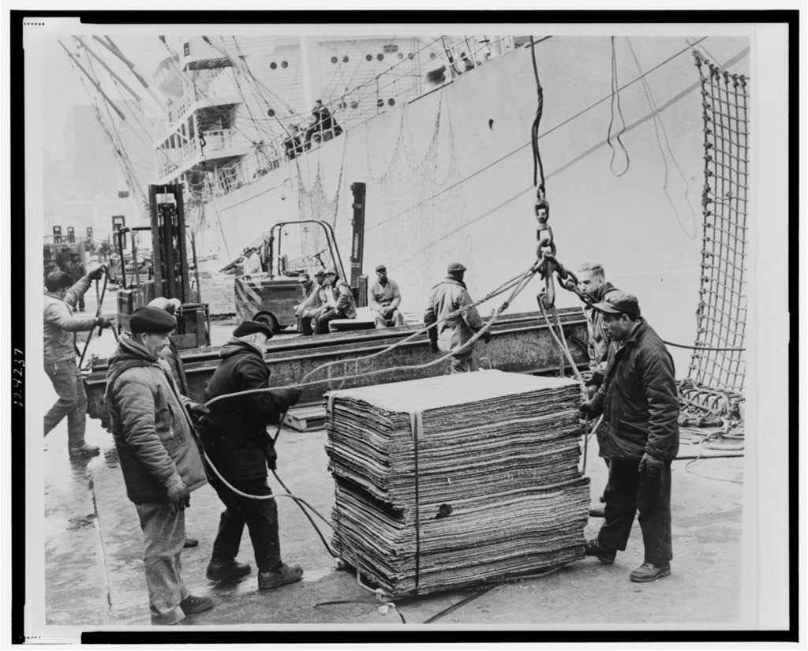

Each handoff consumed labor and time, exposed cargo to loss, and required another organization to coordinate.

The port was the expensive break in the journey.

Breakbulk loading, Brooklyn, 1967 · Library of Congress

## In the chapter example, ports were nearly half the cost

[figure not shown]

A dozen vendors moved one truckload of medicine from Chicago to France circa 1960. The two ports alone cost $1,163 of the $2,386 total.

Levinson, *The Box*, Chapter 1, Table 1

## Before containerization, freight could rival trade barriers

In 1961, U.S. exporters spent about **12 cents of every export dollar** on ocean freight.

12%

ocean freight as a share of U.S. export value

7%

average U.S. import tariff

Moving goods across oceans could cost more than the formal tariff barrier.

# Building the Container System

## Fifty-eight boxes sailed from Newark in 1956

[figure not shown]

Separated the container from the truck chassis and designed a continuous handoff among truck, ship, and rail.

*Ideal-X*, 1956 · Maersk/SeaLand

## One fitting made different networks compatible

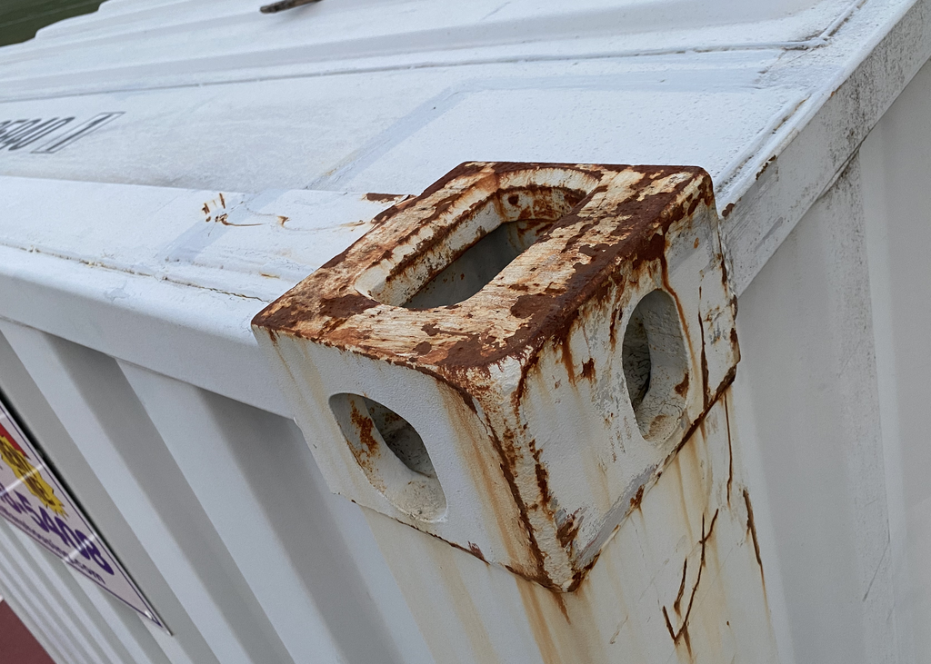

A standard corner casting lets cranes, chassis, rail cars, and ships handle the same box.

Compatibility required common *standards* for dimensions, fittings, strength, identification, and operating rules.

**The corner fitting itself is standardized under ISO 1161.**

ArnoldReinhold / Wikimedia Commons · CC BY-SA 4.0

## ISO: who sets international standards?

### What?

An **independent, nongovernmental organization** whose members are national standards bodies.

### Where?

Its **Central Secretariat is in Geneva, Switzerland**.

### When?

ISO was founded in **1947**. Its freight-container committee, **TC 104**, was created in **1961**.

### Why?

Common voluntary standards let firms and countries build **compatible products and infrastructure** without a single company controlling the system.

[figure not shown]

**Relevant here: ISO/R 668:1968** established the core classification, dimensions, and ratings for Series 1 freight containers.

ISO · Geneva headquarters · ISO/R 668:1968

## A container port operates like a factory

[figure not shown]

[figure not shown]

Panama · Course photograph

## The box reduced five costs at once

[figure not shown]

Containerization lowered total landed cost by reducing handling, delay, risk, and coordination costs as well as freight charges.

## Malaysia to Cincinnati in 28 days, unopened

[figure not shown]

Economists: it is now better to assume that moving goods is essentially costless than to assume it is an important component of production.

## Why the payoff took a decade

[figure not shown]

The payoff waited for standards, infrastructure, organizational redesign, and agreements over dock labor, port investment, and regulation.

Edison had the incandescent bulb by 1879. Twenty years later, 3 percent of American homes had electric light.

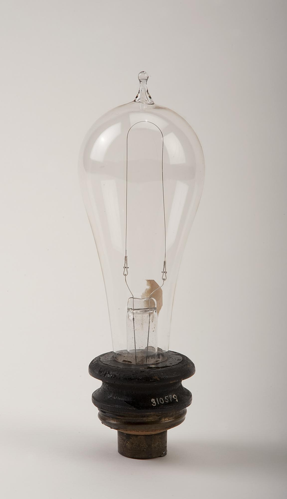

Edison lamp · Smithsonian Institution

# Where Things Are Made

## Ricardo’s model assumed away shipping costs

[figure not shown]

Ricardo’s 1817 wine-and-cloth example compared **production costs** in England and Portugal. Moving the goods between them cost nothing in the model.

Comparative advantage explains why specialization can create gains. Transport costs help determine whether specialization across distance is viable.

David Ricardo, c. 1821 · Thomas Phillips / National Portrait Gallery

## Multinational plants became one production network

[figure not shown]

Firms could reorganize production across viable locations as wages, exchange rates, capabilities, and other conditions changed.

## Fragmented production created two core IB decisions

### Where?

Where should each activity take place?

Wages · skills · infrastructure · market access · risk

### Who?

Who should perform it?

The firm itself · an outside supplier

Lower trade costs expanded the set of viable locations and suppliers. We will study this later in the semester.

## Trade surged, but causation remains difficult

2×

manufactured trade grew more than twice as fast as manufacturing output in the decade after 1966

### What else changed?

Tariffs · exchange rates · oil shocks · computers

How could we isolate the container’s effect?

Propose a comparison that could separate the container from the other changes.

## The same people gained as consumers and faced new competition at work

### As consumers

**4× more imported product varieties** in the United States, 2002 vs. 1972

Estimated gain from added variety: **nearly 3% of GDP**

### At work

Export hubs gained jobs and investment.

Import-competing workers faced more distant competitors.

[figure not shown]

**France:** some manufacturers shifted production abroad rather than absorb the cost of a shorter workweek with unchanged pay.

Consumer gains were broad. Employment losses were concentrated in particular occupations and places.

## Containerization relocated the port economy

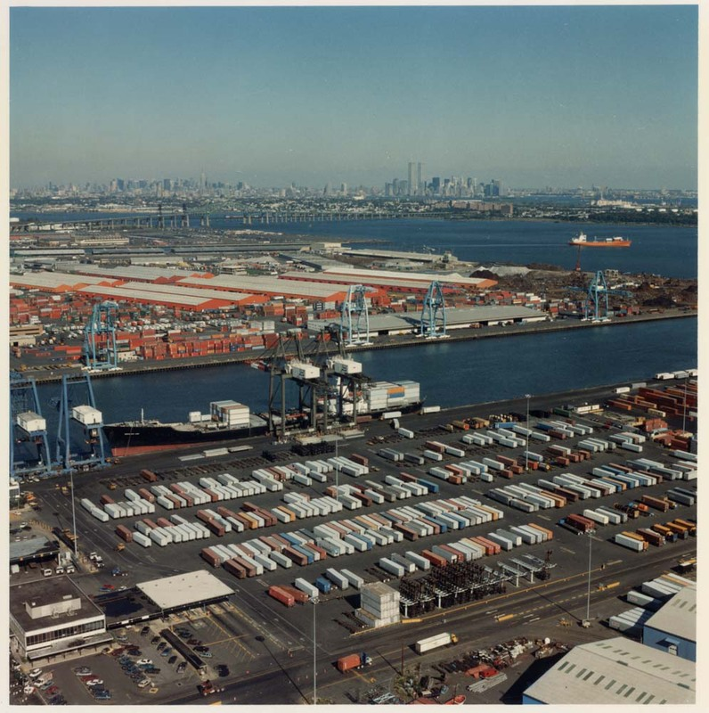

Port Newark, 1996 · SCI Archives

New York’s finger piers lacked the contiguous land and surface connections container terminals required.

Port activity shifted to large terminals at **Newark and Elizabeth, New Jersey**, just west of New York City. Waterfront employment and investment moved with it.

# Distance Still Matters

## What still resists distance?

**Running shoes · fresh flowers · cars · cement · accounting software · haircuts**

Rank them from **easiest to hardest to serve from 5,000 miles away**. For each, name the transport or coordination cost that drives your ranking.

Value-to-weight, perishability, transport mode, and the need for face-to-face delivery still shape what can be traded over distance.

## Cheap freight did not erase location

### Containerization changed

Handling · inventory · reliability · coordination

### Border frictions still divide markets

Currencies · jurisdictions · trade rules · political risk

Why do firms keep production in high-wage locations?

# Group Activity: How Much Did the Container Matter?

## 1985 without containerization

Cargo still crosses ports piece by piece. Jet travel, computers, oil shocks, and tariff reductions are unchanged.

1. Japanese cars in the United States
2. Walmart
3. Shenzhen manufacturing
4. Toyota just-in-time production
5. New York garment district decline
6. Nespresso capsule
7. Bangalore software services
8. Kenyan cut flowers

**10 minutes · Groups of four**

Without containerization, is your example **mostly unchanged · later/smaller · unlikely in this form**?

Name **one mechanism** that explains your choice.

## Reflection: return to your IB Voice

What exactly did the box change, and why did its largest effects take a decade to appear?

Revise your opening answer. Which link in your causal argument changed?

Standards, complementary investment, organizational change, and policy lowered total landed cost. Global competition and fragmented production followed.

Tomorrow: one production network, many currencies.